# Week 5 Day 1 Homework

```r
colscheme <- colors(c("#E89FE9", "#50434F", "#B6A7B5", "#F9A472", "#BD7040"))
```

```
Error in if (distinct) c[!duplicated(t(col2rgb(c)))] else c :
  the condition has length > 1
```

```r
qb_revenue_breakdown <- clean_names(qb_revenue_breakdown)

qb_competitors <- clean_names(qb_competitors)

qb_device_data <-  clean_names(qb_device_data)

qb_monthly_sales <- clean_names(qb_monthly_sales)

qb_revenue_breakdown
```

| product | year | revenue |
| --- | --- | --- |
| Trackers | 2019 | 8994 |
| Smart Watches | 2019 | 12003 |
| Accessories | 2019 | 5250 |
| Subscription Services | 2019 | 3750 |
| Trackers | 2018 | 8004 |
| Smart Watches | 2018 | 11000 |
| Accessories | 2018 | 4250 |
| Subscription Services | 2018 | 1005 |

```r
NA
```

## Take the data in the dataset qb_revenue_breakdown and make a stacked bar

chart showing the sources of revenue across the two years in the dataset.

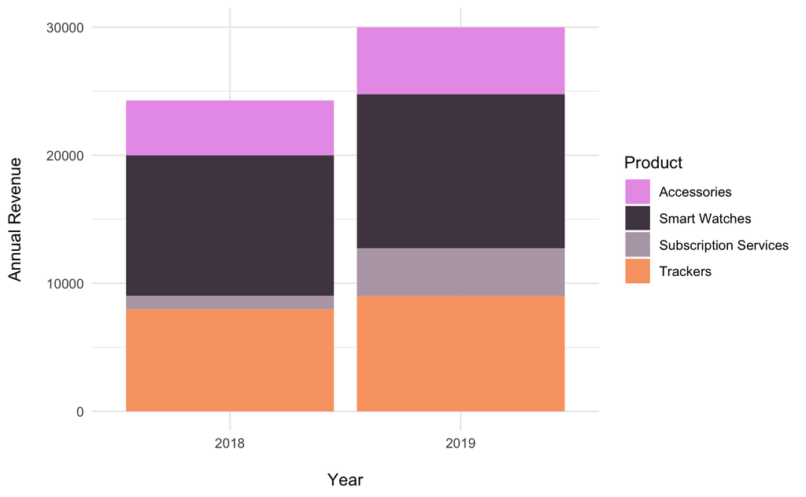

## Make a line chart showing monthly sales of the “flagship product” - the

‘KwikBit Unit 1’ - over the last year. This data is inside qb_monthly_sales, but you will need to use filter() or subset() (base R).

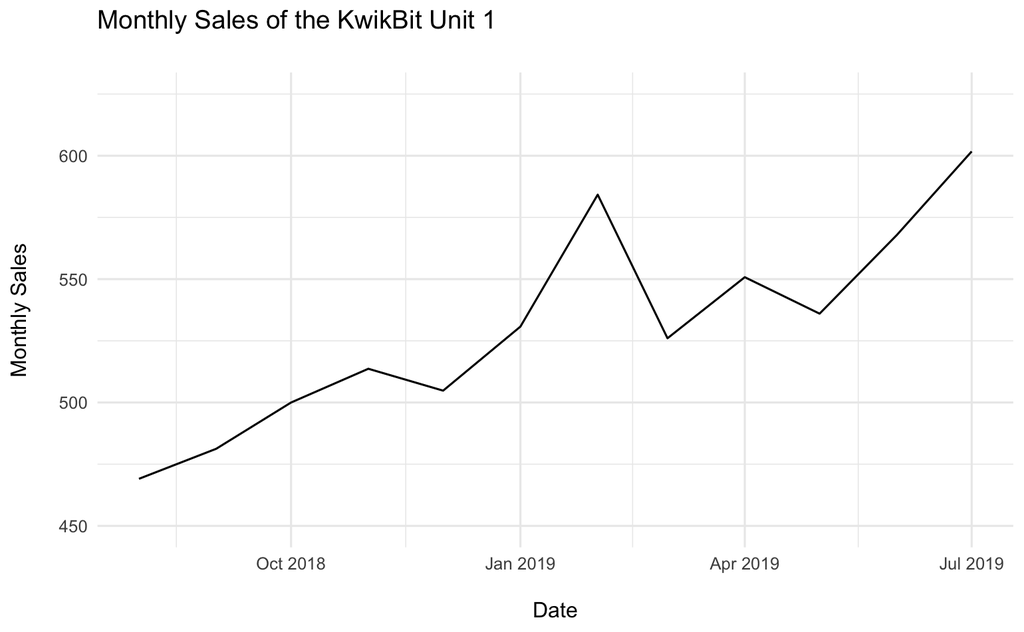

## Make a line chart showing monthly revenue and costs over the last year. This

## data is also in qb_monthly_sales.

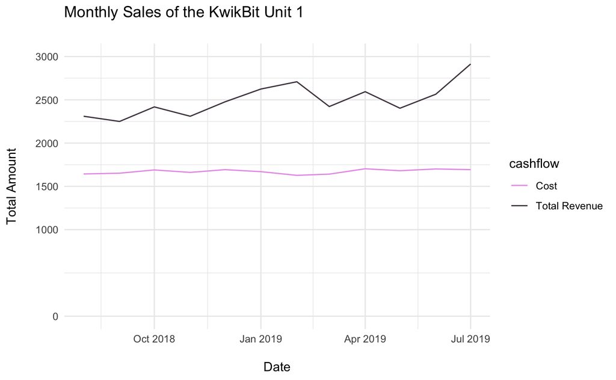

## Show annual sales of personal fitness trackers over the last 5 years broken

## down by company as a ribbon plot (use geom_area). This data is in

## qb_competitors.

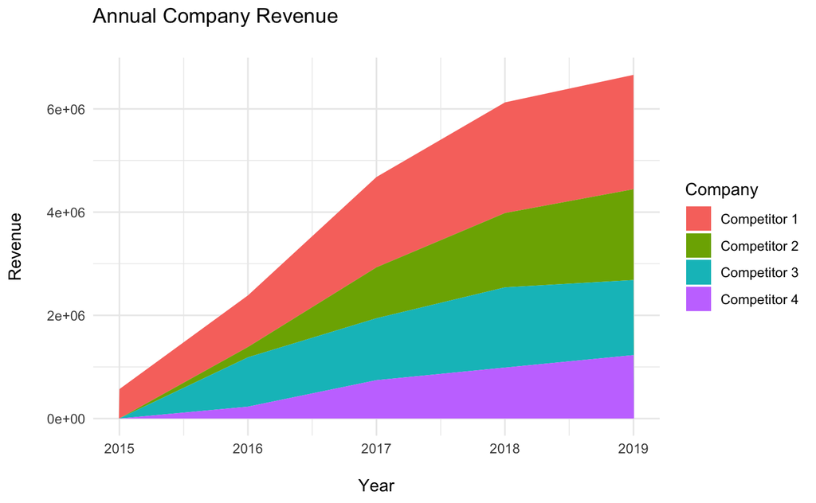

```r
ggplot(qb_competitors) +
  geom_area(aes(x = year,
            y = revenue,
            fill = company)) +
  scale_colour_manual(values = colscheme) +
  labs(
    y = "Revenue\n",
    x = "\nYear",
    fill = "Company",
    title = "Annual Company Revenue\n"
    ) +
  theme_minimal()
```

```r
NA
NA
NA
```

## Now show the sales from the four competitors as a line graph. Include an

## extra layer that shows the data points used to make the lines.

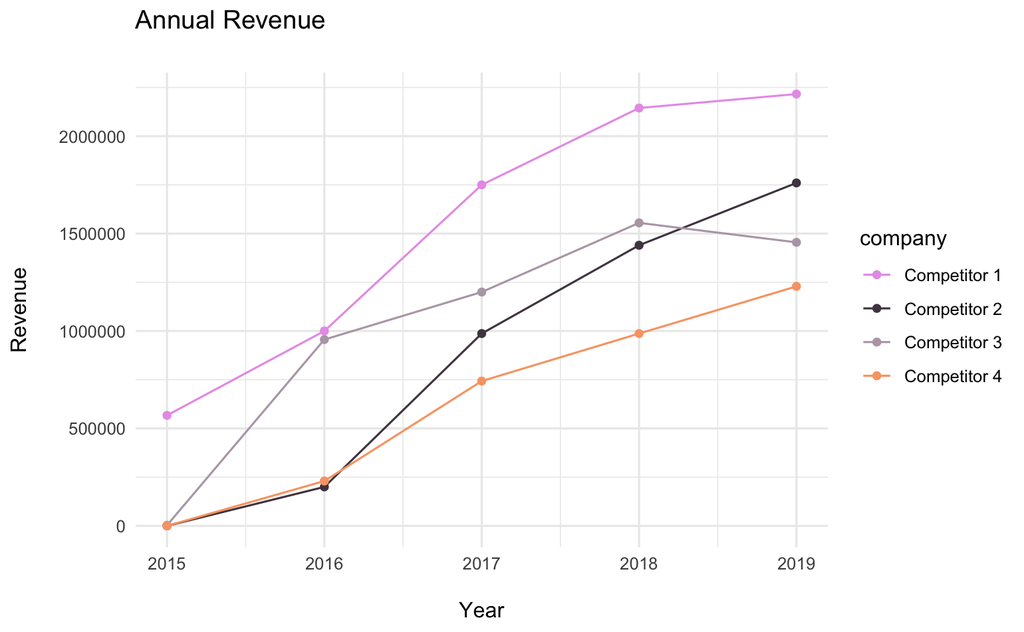

```r
ggplot(qb_competitors) +
  geom_line(aes(x = year,
                y = revenue,
                colour = company
                )) +
  geom_point(aes(x = year,
                y = revenue,
                colour = company
                )) +
  scale_colour_manual(values = colscheme) +
  labs(
    x = "\nYear",
    y = "Revenue\n",
    fill = "Company",
    title = "Annual Revenue\n"
  ) +
  theme_minimal()
```

## Now the company wants to compare the number of steps that their device counts

## vs. their competitors. Make a line graph of the number of steps throughout

##time, and use faceting to compare between companies and people. The data for ## this is in qb_device_data.

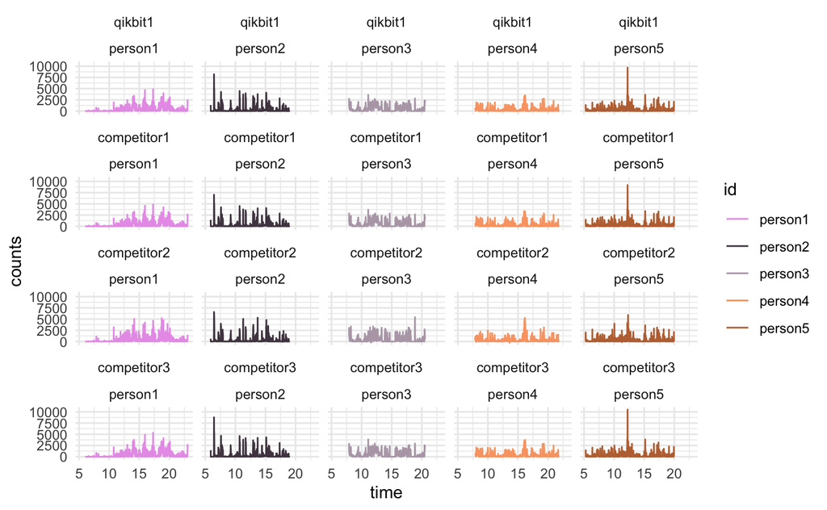

```r
qb_device_united <- qb_device_data %>%
  mutate(mins = mins/60) %>%
  mutate(time = hours+mins) %>%
  select(-hours, -mins)



ggplot(qb_device_united) +
 geom_line(aes(x = time,
      y = counts,
      colour = id)) +
  facet_wrap(device ~ id) +
  scale_colour_manual(values = colscheme) +
  theme_minimal()
```